# Chapter 06 cont., Problem Set Key

### 6.6

Equations 6a and 6b can be thought of as each having two parts, a growth part and a mortality part. For the prey equation, the growth part is
$$rV\left(1 - \frac{V}{K}\right)$$
and the mortality part is ($aVP$). The mortality part says how the prey population is being reduced by the predator, which is basically the same as how many prey the predators are eating, or the predation rate. So each predator eats at the rate $aV$. Make a graph of the predation rate as a function of $V$, assuming that $a = 0.5$ (i.e., during the relevant time period, each predator eats $0.5V$ prey). Examining the graph, does it make biological sense? Imagine yourself as a predator eating olives. If there are 2 olives on your plate, how many of them will you eat? If there are 10, how many will you eat? If there are 10,000, how many will you eat? Sketch onto the graph what you think might be a more biologically reasonable assumption about the shape of that curve (ask yourself how many of the 10,000 olives you are really likely to eat).

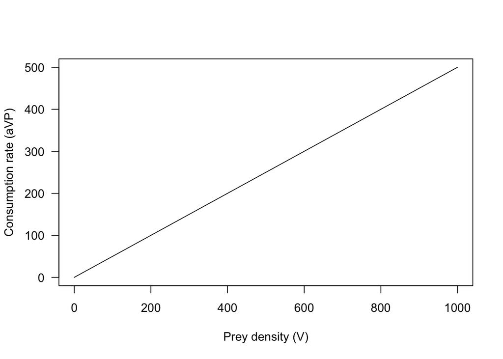

```r
V <- seq(from = 0, to = 1e3)

a <- 0.5
fV <- V*a

plot(x = V, y = fV, xlab = "Prey density (V)", ylab = "Consumption rate (aVP)", las = 1, type = "l")
```

To me, a reasonable function would have a maximum consumption rate. That is, as the olives increase in density, there are only so many I can grab, chew, and swallow. At first there might not be a difference between 1, 2, or 3 olives, but as there are more and more, I definitely have a finite maximum rate of consumption. I imagine the curve would begin linear, but asymptote.

### 6.7

Carnivorous tunicates are sessile, so they must wait for their food to come their way. How many food items will a tunicate eat in a given period of time? Suppose that the overall time they allot to eating during the day is 12 hours (tunicates sleep the rest of the time), and each time a food item is taken in, an individual tunicate requires half an hour to swallow it. The frequency at which food items come its way will depend on the density of those food items. The time required to encounter a food item will be inversely related to the density of the food items, or $1/V$. What is the equation that relates the total number of food items eaten in a day to the population density of the food? Make a graph of the equation for values of $V$ from 0 to 30.

It takes 0.5 hr. to process/handle the food item, it will take $1/V$ hr. encounter a food item, and there will be a total of
$$\frac{12}{0.5 + \frac{1}{V}}$$
in a 12-hr. period. This can be rewritten as
$$\frac{12V}{1 + 0.5V}$$
This can be graphed:

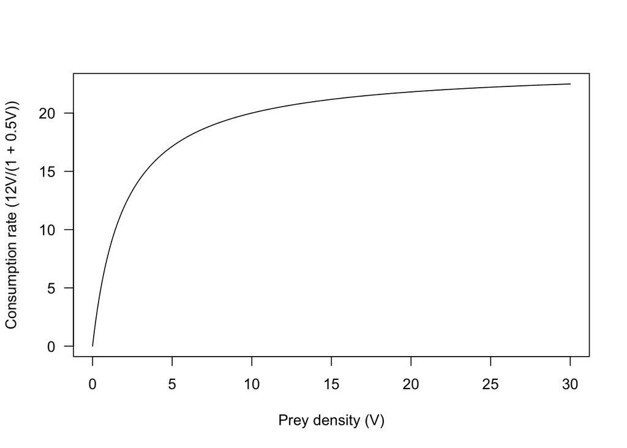

```r
V <- seq(from = 0, to = 30, by = 0.01)
fV <- 12*V / (1 + 0.5*V)

plot(x = V, y = fV, xlab = "Prey density (V)", ylab = "Consumption rate (12V/(1 + 0.5V))", las = 1, type = "l")
```

### 6.8

If the number of prey eaten is $V_e$ and the number available is $V$, rewrite the equation derived in exercise 6.7 after transforming the variables to $v_e = 1/V_e$ and $v = 1/V$ such that $v_e$ is presented as a function of $v$. What can you say in words about the relationship between the inverse of food eaten as related to the inverse of food offered?

6.7 yielded
$$\text{Prey eaten} = \frac{12V}{1 + 0.5V}$$
We can write this as:
$$V_e = \frac{12V}{1 + 0.5V},$$
and substitute $V_e = 1/v_e$ and $V = 1/V$:
$$\frac{1}{v_e} = \frac{12\left(\frac{1}{v}\right)}{1 + 0.5\left(\frac{1}{v}\right)}.$$
This can be rewritten as
$$\frac{1}{v_e} = \frac{12}{v\left(1 + 0.5\left(\frac{1}{v}\right)\right)}$$
and multiplied through as
$$\frac{1}{v_e} = \frac{12}{v + 0.5}.$$
Soving for $v_e$, you arrive at:
$$v_e = \frac{0.5}{12} + \frac{1}{12}V$$
The inverse of the food eaten and the inverse of food offered is a linear relationship.

### 6.9

The following pairs of numbers represent the number of aphids eaten and the number offered in an experiment with a ladybird beetle and its aphid prey: 18, 25; 34, 50; 60, 100; 95, 200; 108, 300; 122, 400; 125, 500; 132, 600; 141, 700; and 145, 800. Use the equation you derived in exercise 6.8 to estimate a general function that fits the data.

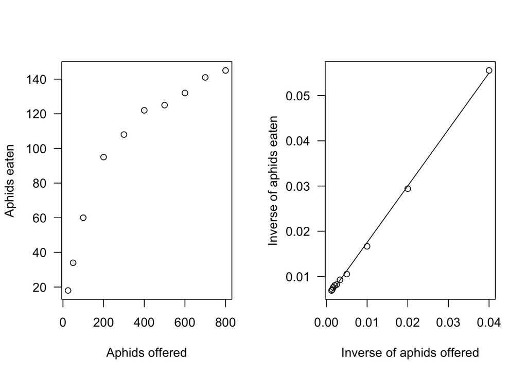

```r
eaten <- c(18, 34, 60, 95, 108, 122, 125, 132, 141, 145)
offered <- c(25, 50, 100, 200, 300, 400, 500, 600, 700, 800)

ve <- 1/eaten
v <- 1/offered

ve.lm <- lm(ve ~ v)
x.range <- seq(from = min(v), to = max(v), length.out = 100)
ve.exp <- ve.lm$coefficients["(Intercept)"] + ve.lm$coefficients["v"]*x.range

par(mfrow = c(1, 2))
plot(x = offered, y = eaten, las = 1, xlab = "Aphids offered", ylab = "Aphids eaten")
plot(x = v, y = ve, las = 1, xlab = "Inverse of aphids offered", ylab = "Inverse of aphids eaten")
  lines(x = x.range, y = ve.exp)
```

### 6.10

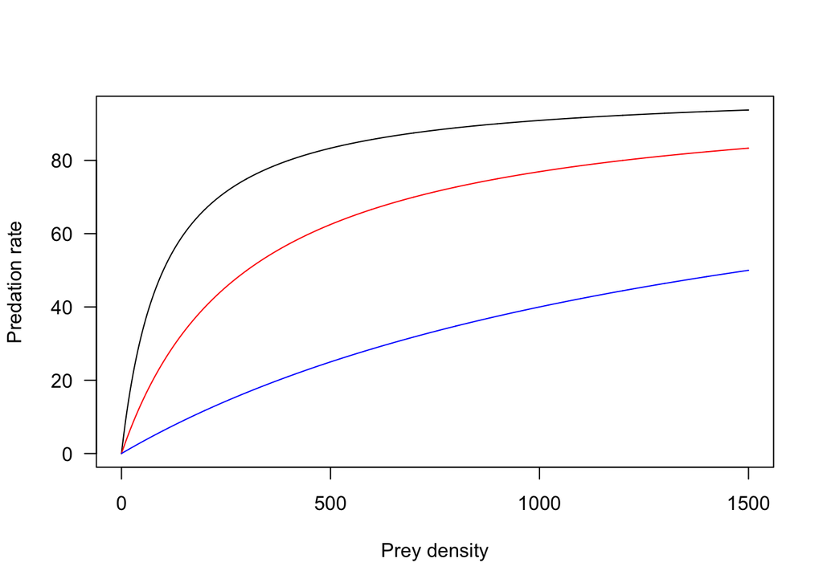

```r
V <- seq(from = 0, to = 1500, by = 1)
FR <- function(c = 100, g, x = V) {
  c*x/(g + x)
}

g100 <- FR(g = 100)
g300 <- FR(g = 300)
g1500 <- FR(g = 1500)

plot(x = V, y = g100, type = "l", las = 1, xlab = "Prey density", ylab = "Predation rate")
  lines(x = V, y = g300, col = "red")
  lines(x = V, y = g1500, col = "blue")
```

### 6.11

The prey isocline with the type II functional response added is $P = (r/c)(g + V)$. Graph that for $r = 1.4$, $g = 50$, and $c = 50$. Graph it again for $r = 1.5$, $g = 100$, and $c = 95$.

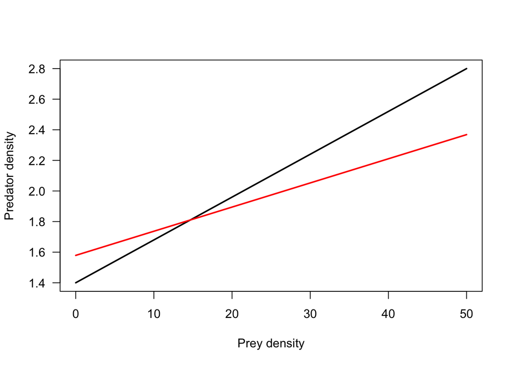

```r
V <- seq(from = 0, to = 50, by = 1)

r <- 1.4
g <- 50
c <- 50
P1 <- (r/c)*(g + V)

r <- 1.5
g <- 100
c <- 95
P2 <- (r/c)*(g + V)

plot(x = V, y = P1, type = "l", lwd = 2, las = 1, xlab = "Prey density", ylab = "Predator density")
  lines(x = V, y = P2, lwd = 2, col = "red")
```

### 6.12

Combine the prey equation that includes density dependence (equation 6a) with the idea of a type II functional response. Write the differential equation, and solve for the isocline.

The differential equation:
$$\frac{\mathrm{dV}}{\mathrm{d}t} = rV\left(\frac{K - V}{K}\right) - \frac{cVP}{g + V}$$

The isocline:

$$\begin{aligned}
\frac{\mathrm{dV}}{\mathrm{d}t} &= rV\left(\frac{K - V}{K}\right) - \frac{cVP}{g + V} \\
0 &= rV\left(\frac{K - V}{K}\right) - \frac{cVP}{g + V} \\
0 &= V\left(r\left(\frac{K - V}{K}\right) - \frac{cP}{g + V}\right) \\
V^* &= 0\text{ is onen isocline}\\
0 &= r\left(\frac{K - V}{K}\right) - \frac{cP}{g + V} \\
\frac{cP}{g + V} &= r\left(\frac{K - V}{K}\right) \\
cP{g + V} &= r\left(\frac{K - V}{K}\right)(g + V) \\
P^* &= r\left(\frac{K - V}{K}\right)(g + V)c^{-1} \\
&\text{Above is fine, but I am going to rewrite it with each term being $V^{n}$}\\
P^* &= -\left(\frac{r}{Kc}\right)V^2 + \left(\frac{r(K - g)}{Kc}\right)V + \frac{gr}{c}
\end{aligned}$$

### 6.13

$$P^* = -\left(\frac{r}{Kc}\right)V^2 + \left(\frac{r(K - g)}{Kc}\right)V + \frac{gr}{c}$$

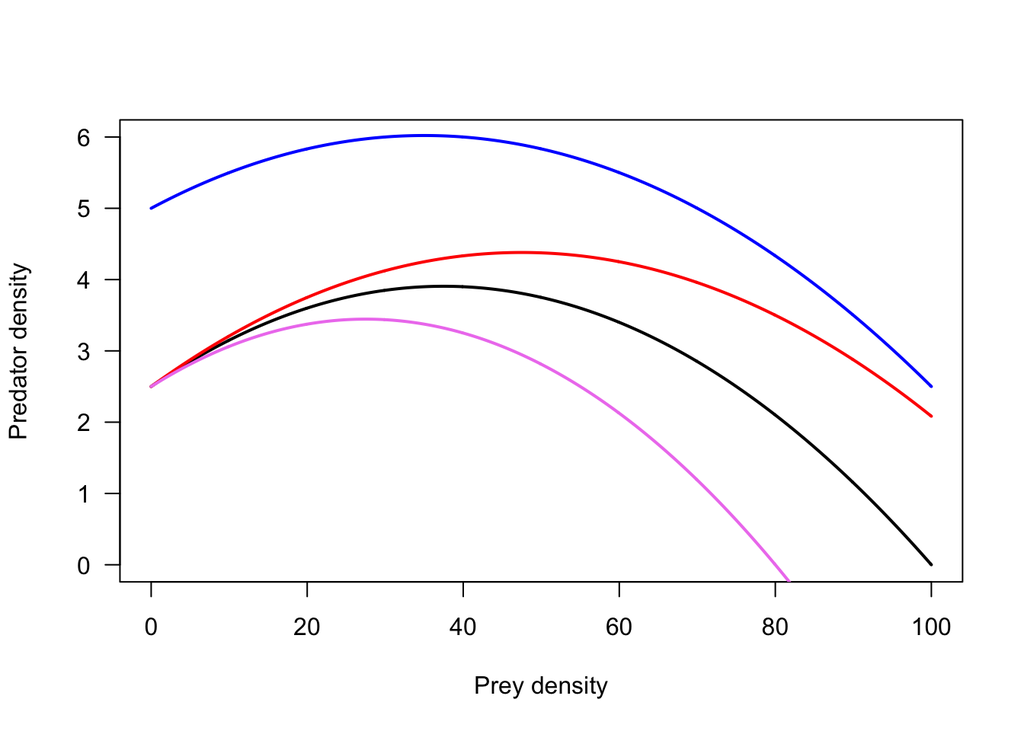

```r
prey.dens <- seq(from = 0, to = 100, by = 0.1)

prey.iso <- function(r, c, K, g, V) {
  PStar <- -r*V*V/(K*c) + (r*(K - g)/(K*c))*V + g*r/c
  return(PStar)
}

r <- 5
c <- 50
K1 <- 100
K2 <- 120
K3 <- 120
K4 <- 80
g1 <- 25
g2 <- 25
g3 <- 50
g4 <- 25 # in the answers it's 50

prey.iso1 <- prey.iso(r = r, c = c, K = K1, g = g1, V = prey.dens)
prey.iso2 <- prey.iso(r = r, c = c, K = K2, g = g2, V = prey.dens)
prey.iso3 <- prey.iso(r = r, c = c, K = K3, g = g3, V = prey.dens)
prey.iso4 <- prey.iso(r = r, c = c, K = K4, g = g4, V = prey.dens)

plot(x = prey.dens, y = prey.iso1, las = 1, xlab = "Prey density", ylab = "Predator density", type = "l", lwd = 2, ylim = c(0, 6))
  lines(x = prey.dens, y = prey.iso2, lwd = 2, col = "red")
  lines(x = prey.dens, y = prey.iso3, lwd = 2, col = "blue")
  lines(x = prey.dens, y = prey.iso4, lwd = 2, col = "violet")
```

### 6.14

Repeat exercise 6.13 but with the parameters $r$,$c$,and $g$ set at 1, 50, and 25,respectively, and vary $K$ from 50 to 100 to 130 to 150. Plot the results on a graph of $P$ versus $V$.

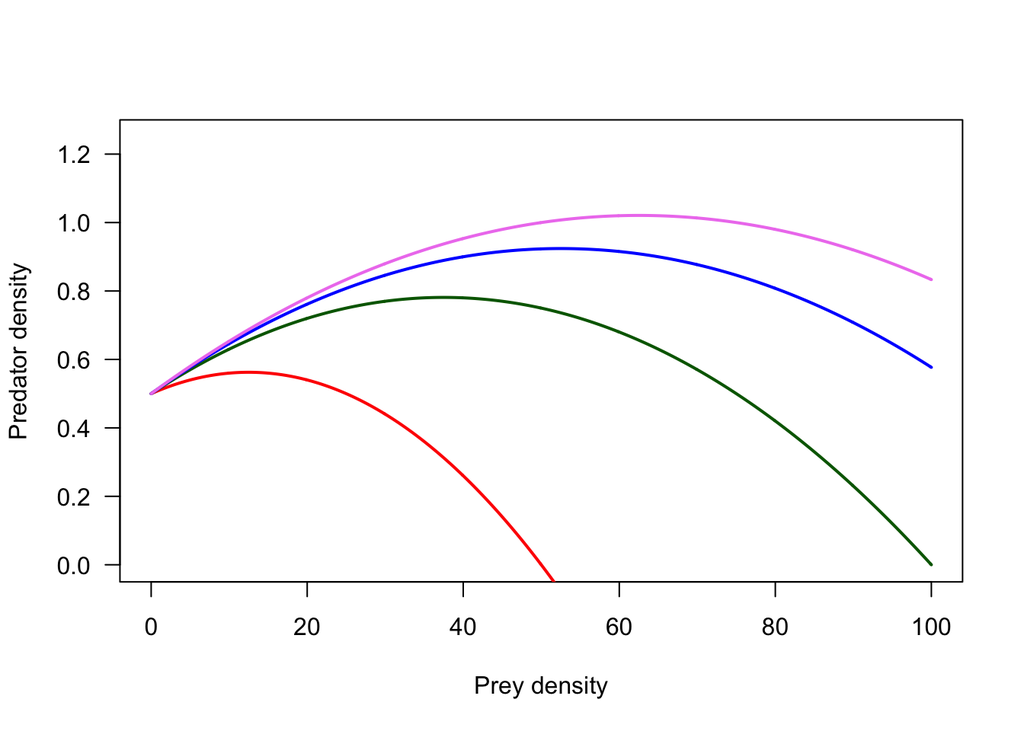

```r
prey.dens <- seq(from = 0, to = 100, by = 0.1)

prey.iso <- function(r, c, K, g, V) {
  PStar <- -r*V*V/(K*c) + (r*(K - g)/(K*c))*V + g*r/c
  return(PStar)
}

K.vec <- c(50, 100, 130, 150)

plot(x = NA, type = "n", xlim = c(0, 100), ylim = c(0, 1.25), xlab = "Prey density", ylab = "Predator density", las = 1)
color.vec <- c("red", "dark green", "blue", "violet")

for (i in 1:length(K.vec)) {
  prey.iso.out <- prey.iso(r = 1, c = 50, g = 25, K = K.vec[i], V = prey.dens)
  lines(x = prey.dens, y = prey.iso.out, col = color.vec[i], lwd = 2)
}
```

### 6.15

Repeat exercise 6.13 but with the parameters $r$, $c$, and $K$ set at 1, 50, and 200, respectively, and vary $g$ from 10 to 35 to 50 to 100.

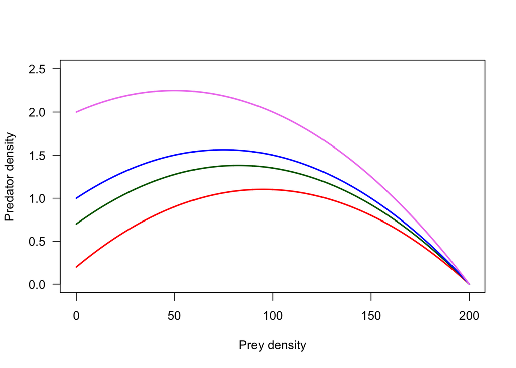

```r
prey.dens <- seq(from = 0, to = 200, by = 0.1)

prey.iso <- function(r, c, K, g, V) {
  PStar <- -r*V*V/(K*c) + (r*(K - g)/(K*c))*V + g*r/c
  return(PStar)
}

g.vec <- c(10, 35, 50, 100)

plot(x = NA, type = "n", xlim = c(0, 200), ylim = c(0, 2.5), xlab = "Prey density", ylab = "Predator density", las = 1)
color.vec <- c("red", "dark green", "blue", "violet")

for (i in 1:length(K.vec)) {
  prey.iso.out <- prey.iso(r = 1, c = 50, K = 200, g = g.vec[i], V = prey.dens)
  lines(x = prey.dens, y = prey.iso.out, col = color.vec[i], lwd = 2)
}
```

### 6.16

Iterate the basic discrete model for 130 iterations with parameters $b_1 = 1.1$, $m = 0.8$, $b = 0.5$, and $m_2 = 0.002$. Plot the time series over time.

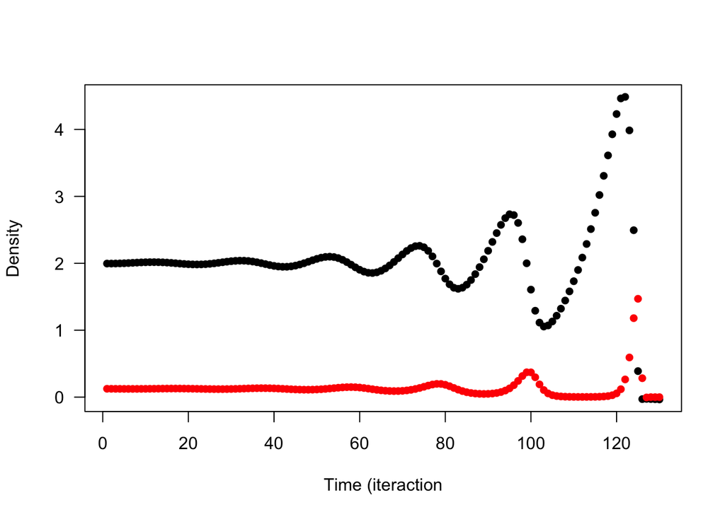

```r
iterations <- 130

lv.disc <- function(t, y, parms) {
  with(as.list(c(y, parms)), {
    Vt1 <- b1*V - m*P*V
    Pt1 <- b*V*P - m2*P
    return(list(c(Vt1, Pt1)))
  })
}

init.dens <- c(V = 1.996, P = 0.125)
parms <- c(b1 = 1.1, m = 0.8, b = 0.5, m2 = 0.002)
time.vec <- 1:iterations

lv.disc.out <- ode(y = init.dens, fun = lv.disc, parms = parms, times = time.vec, method= "iteration")

plot(x = 1:iterations, y = lv.disc.out[,2], las = 1, xlab = "Time (iteraction", ylab = "Density", pch = 16)
  points(x = 1:iterations, y = lv.disc.out[,3], pch = 16, col = "red")
```

### 6.17

An alternative model (to be discussed below) is
$$\begin{aligned}
V_{t+1} &= bV_t \exp (–aP_t) \\
P_{t+1} &= cV_t \exp (1–aP_t).
\end{aligned}$$
Iterate this model for 130 iterations with parameters $c = 1$, $a = 0.3$, and $b = 1.1$. Plot the time series over time. Take logs of the numbers of prey and predators and plot them against one another.

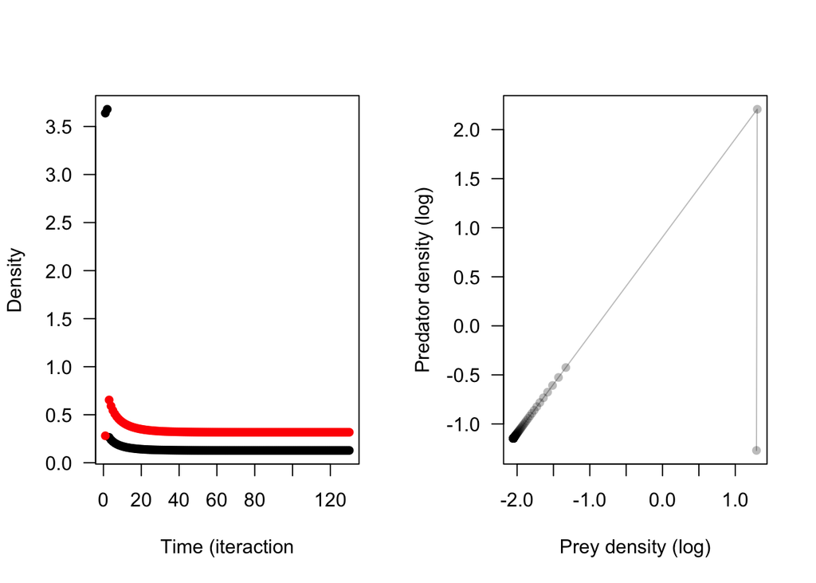

```r
iterations <- 130

lv.disc <- function(t, y, parms) {
  with(as.list(c(y, parms)), {
    Vt1 <- b*V*exp(-a*P)
    Pt1 <- c*V*exp(1 - a*P)
    return(list(c(Vt1, Pt1)))
  })
}

init.dens <- c(V = 3.639, P = 0.2809)
parms <- c(c = 1, b = 1.1, a = 0.3)
time.vec <- 1:iterations

lv.disc.out <- ode(y = init.dens, fun = lv.disc, parms = parms, times = time.vec, method= "iteration")

par(mfrow = c(1, 2))
plot(x = 1:iterations, y = lv.disc.out[,2], las = 1, xlab = "Time (iteraction", ylab = "Density", pch = 16)
  points(x = 1:iterations, y = lv.disc.out[,3], pch = 16, col = "red")

plot(x = log(lv.disc.out[,2]), y = log(lv.disc.out[,3]), xlab = "Prey density (log)", ylab = "Predator density (log)", las = 1, type = "l", col = "#00000044")
  points(x = log(lv.disc.out[,2]), y = log(lv.disc.out[,3]), pch = 16, col = "#00000044")
```